# TP Modelado 2

# Modelado

Tres elementos de la tarea de modelado

1. Representación
2. Evaluación
3. Optimización

Usando el dataset penguins del paquete palmerpenguins queremos crear un modelo que permita estimar el largo del pico conociendo el peso de los pingüinos.

> $x$: Peso del pingüino

> $\hat y$: Largo del pico

En principio vamos a trabajar sólo con los pingüinos de la especie Gentoo.

Antes de empezar a construir el modelo, grafiquen! Hagan un scatter plot del largo del pico en función del peso para los pingüinos Gentoo.

```r
library(dplyr)
library(tidyverse) # Para usar drop_na()
```

```r
library(ggplot2)
library(palmerpenguins)

head(penguins)
```

```
## # A tibble: 6 x 8
##   species island bill_length_mm bill_depth_mm flipper_length_… body_mass_g sex
##   <fct>   <fct>           <dbl>         <dbl>            <int>       <int> <fct>
## 1 Adelie  Torge…           39.1          18.7              181        3750 male
## 2 Adelie  Torge…           39.5          17.4              186        3800 fema…
## 3 Adelie  Torge…           40.3          18                195        3250 fema…
## 4 Adelie  Torge…           NA            NA                 NA          NA <NA>
## 5 Adelie  Torge…           36.7          19.3              193        3450 fema…
## 6 Adelie  Torge…           39.3          20.6              190        3650 male
## # … with 1 more variable: year <int>
```

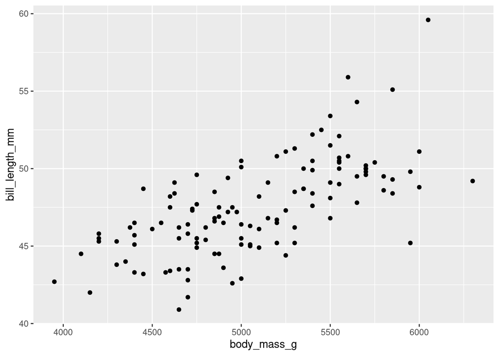

```r
datos <- penguins %>%
    rowwise() %>%
    mutate(species = toString(species)) %>%
    filter(species == "Gentoo") %>%
    select(bill_length_mm, body_mass_g) %>%
    drop_na()

datos %>%
    ggplot(aes(body_mass_g, bill_length_mm)) +
        geom_point()
```

El primer paso es la representación o especificación del modelo. Es decir, definir cómo se relacionan las variables largo de pico y peso según el modelo. En este caso vamos a usar una función lineal. ¿Tiene sentido proponer este modelo de acuerdo a cómo se ven los datos en el gráfico que hicieron?

Aunque este problema se puede resolver con la función ´lm()´, entre otras, en este caso vamos a hacer explícitos los tres pasos que requiere el modelado.

## 1. Representación

> Crear una función que tenga como inputs la ordenada al origen, la pendiente y el peso, y como output el largo del pico.

```r
modelo.lineal <- function(x, ordenada=0, pendiente=1){
    y <- pendiente * x + ordenada
    return (y)
}
```

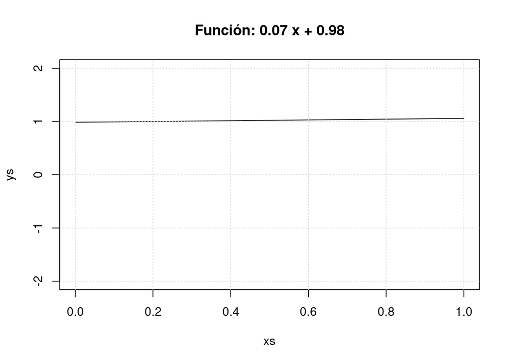

```r
#set.seed(42)

a <- runif(1, min=-1, max=1)
b <- runif(1, min=0, max=1)

xs <- c(0,1)

ys <- modelo.lineal(xs, b, a)


plot(xs, ys,
    xlim = c(0, 1),
    ylim = c(-2, 2),
    type = 'l',
    main = paste0("Función: ", round(a, 2), " x + ", round(b, 2))
    )
grid()
```

## 2. Evaluación

> El siguiente paso es la evaluación. Es decir, dado un modelo con sus parámetros, queremos conocer una medida del ajuste del modelos a los datos.

> Para eso vamos a crear una función que tenga como inputs la variable a explicar (largo del pico) y las predicciones del modelo.

```r
root.mean.squared.error <- function(y.real, y.pred){
    e <- sum( (y.real - y.pred) ^ 2 )
    return (e)
}
```

```r
root.mean.squared.error(c(1, 2, 3), c(0, 0, 0))
```

```
## [1] 14
```

## 3. Optimización

> Por último, la optimización. Es decir, cómo vamos a encontrar los parámetros que minimizan la función de pérdida.

> En este caso vamos a usar un método de **optimización aleatoria**. Es decir, queremos una función que:

> * defina valores iniciales de parámetros `(a, b)` y un rango inicial de cada parámetro.

> * evalúe el *RMSE* inicial.

> * sortee nuevos parámetros dentro de la región definida y evalúe el *RMSE* para estos nuevos parámetros.

> * si el *RMSE* disminuye, tomo los nuevos valores de `(a,b)` y si no achico la región de búsqueda.

> * Cuando la región de búsqueda es lo suficientemente chica, termina y devuelve los parámetros finales.

```r
set.seed(42)
optim.aleatoria <- function(datos,
                            loss.fun=root.mean.squared.error,
                            pendiente.ini=0.01, ordenada.ini=1){
  facred <- 0.9999  # factor de reduccion de la ventana
  facred.acu <- 1   # factor de reduccion acumulado
  toler <- 1e-6     # umbral de tolerancia

  # Rangos
  rango.pendiente <- 10 # rango inicial de mu
  rango.ordenada <- 100 # rango inicial de alfa

  # Parametros iniciales
  #mu <- 100000 # valor inicial de mu
  #alfa <- 1000 # valor inicial de alfa
  #beta <- 1000 # valor inicial de beta

  # Parametros mejores
  mejor.pendiente <- pendiente.ini
  mejor.ordenada <- ordenada.ini

  y.real <- datos$bill_length_mm
  y.pred <- modelo.lineal(x = datos$body_mass_g,
                          ordenada = mejor.ordenada,
                          pendiente = mejor.pendiente)

  mejor.eval <- loss.fun(y.real, y.pred) # el mejor valor
  mejores <- matrix(c(mejor.eval, pendiente.ini, ordenada.ini, 1), 1, 4)
  k <- 0    # indice de iteracion
  actu <- 0 # indice de actualizacion

  # Historiales para graficar luego
  pendiente.hist <- c()
  ordenada.hist <- c()

  while (facred.acu > toler)
  {
    k <- k + 1

    # Genero nuevos valores aleatorios
    pendiente <-
      runif(1,
            mejor.pendiente - rango.pendiente * facred.acu,
            mejor.pendiente + rango.pendiente * facred.acu)
    ordenada <-
      runif(1,
            mejor.ordenada - rango.ordenada * facred.acu,
            mejor.ordenada + rango.ordenada * facred.acu)

    # Evaluación de los nuevos valores
    y.pred <- modelo.lineal(x = datos$body_mass_g,
                            ordenada = ordenada,
                            pendiente = pendiente)
    valor <- loss.fun(y.real, y.pred)

    #cat(valor, "\n\n", y.pred, "\n\n", y.real, "-------------------- \n\n")
    #print(data.frame(y.real, y.pred))
    #cat("Error:", valor)
    #invisible(readline(prompt=paste0(k, " - Presione [enter] para seguir:")))

    if (valor < mejor.eval)
    {
      # Si encuentro algo mejor -> Actualizacion
      actu <- actu + 1

      mejor.eval <- valor
      mejor.pendiente <- pendiente
      mejor.ordenada <- ordenada

      pendiente.hist <- c(pendiente, pendiente.hist)
      ordenada.hist <- c(ordenada, ordenada.hist)

      mejores <- rbind(mejores, c(mejor.eval, pendiente, ordenada, k))
    }
    else
    {
      # Si NO encuentro algo mejor -> Reduzco rango de busqueda
      facred.acu <- facred.acu * facred
    }
  }
  #all.hist <- data.frame(mejor.eval, pendiente.hist, ordenada.hist)
  all.hist <- data.frame(pendiente.hist, ordenada.hist)
  return (list(mejores, all.hist))
}
```

Mas detalles en el [apunte](https://guillermosolovey.github.io/laboratoriodedatos2021-2C/NotebooksTeoricas/Modelado/Modelado_con_Regresion_Lineal_Multiple_Final.pdf) y [videos](https://youtube.com/playlist?list=PLN2e9R_DoC0THQgbage3DkS_7tCsqTd-3) de Andres Farall. El factor de reduccion y la tolerancia pueden estar definidas por defecto en la funcion. Por ejemplo, ´0.95´ y ´1e-10´ respectivamente. Tenga en cuenta que esta función tiene que llamar a las otras dos funciones creadas anteriormente.

## Automatización

d- Usando las 3 funciones creadas, armar un script que cargue los datos, ajuste el modelo, devuelva los parámetros óptimos y grafique los datos y la recta estimada por el modelo.

```r
resul <- optim.aleatoria(datos = datos)
resul
```

```
## [[1]]
##             [,1]        [,2]        [,3]   [,4]
##   [1,] 3949.6900 0.010000000   1.0000000      1
##   [2,] 3250.4675 0.012174875 -16.4747726   8564
##   [3,] 2881.0242 0.011387870 -12.4908242  11500
##   [4,] 2606.1461 0.012025493 -13.8776883  17479
##   [5,] 2366.0516 0.009703802  -4.2200963  23100
##   [6,] 1908.5195 0.009173640   2.8892420  25732
##   [7,] 1840.1962 0.008986808  -0.0401614  26661
##   [8,] 1634.1485 0.009552922  -0.2353345  28811
##   [9,] 1425.7938 0.009119627   1.0901174  31397
##  [10,] 1339.1668 0.008805345   2.5210533  35690
##  [11,] 1277.1291 0.008511471   3.7954223  39306
##  [12,] 1237.7873 0.008397839   5.3077171  39498
##  [13,] 1162.8529 0.008136191   5.8492347  39811
```

[output cut: 1761 more lines]

```r
mejor.params <- resul[[1]][length(resul[[1]][,1]),]
mejor.pendiente <- mejor.params[2]
mejor.ordenada <- mejor.params[3]
```

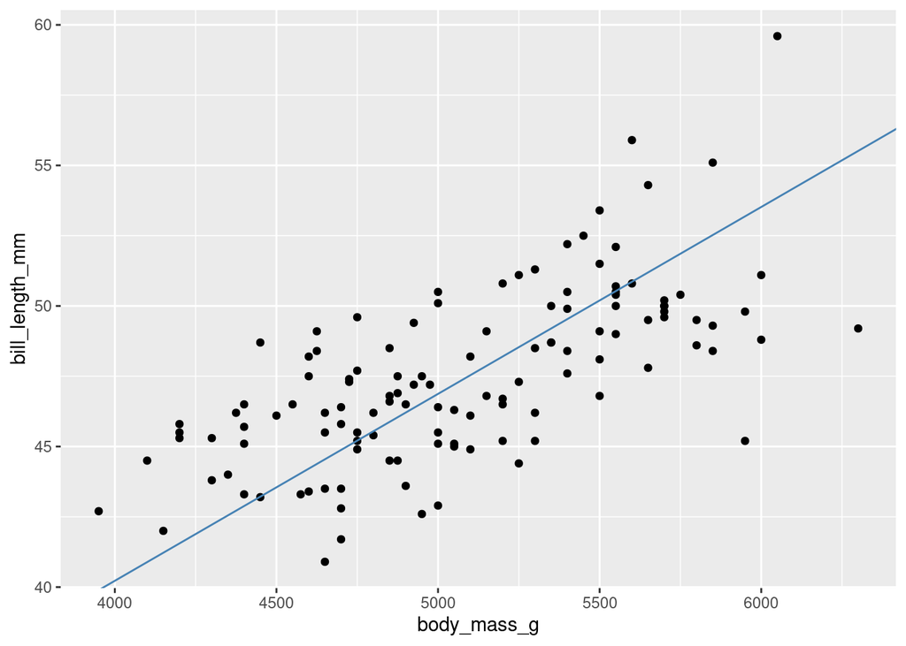

```r
datos %>%
    ggplot(aes(body_mass_g, bill_length_mm)) +
    geom_point() +
    geom_abline(aes(slope=mejor.pendiente, intercept=mejor.ordenada), color="steelblue")
```

e- Si repiten el proceso de optimización aleatoria, ¿llegan a la misma solución? Una propiedad importante de un método de optimización es que sea robusto, en el sentido de que los parámetros óptimos que encuentra el método no sean casualidad. Para estudiar esto, repitan el proceso de optimización 100 veces y hagan una descripción de los parámetros estimados. Pueden hacer un histograma de `a` y de `b`. Estudien también si los valores estimados dependen de los valores iniciales para `a` y `b`.

```r
pendientes <- c()
ordenadas <- c()
errores <- c()
iteraciones <- c()
cat("   Error   \tPendiente \tOrdenada\n")
```

```
##    Error     Pendiente   Ordenada
```

```r
for(i in 1:100){
  resul <- optim.aleatoria(datos = datos)

  mejor.params <- resul[[1]][length(resul[[1]][,1]),]

  pendientes <- c(pendientes, mejor.params[2])
  ordenadas <- c(ordenadas, mejor.params[3])

  errores <- c(errores, mejor.params[1])
  iteraciones <- c(iteraciones, mejor.params[4])

  cat(i, ". ", mejor.params[1], "\t", mejor.params[2], "\t", mejor.params[3], "\n", sep="")
}
```

```
## 1. 643.5359  0.004432675 24.98657
## 2. 642.9293  0.004403354 25.13831
## 3. 648.0295  0.003580506 29.35564
## 4. 640.2028  0.003988341 27.2649
## 5. 654.5935  0.00477669  23.22497
## 6. 651.2445  0.004693453 23.65054
## 7. 639.8765  0.004081731 26.78637
## 8. 681.6104  0.002936322 32.65768
## 9. 640.3614  0.004215716 26.09998
## 10. 639.8739 0.004091526 26.73621
## 11. 640.3266 0.003970625 27.35592
## 12. 639.8799 0.004076999 26.81061
## 13. 655.7217 0.004802081 23.09279
## 14. 685.3195 0.005295696 20.56404
## 15. 639.8741 0.004093096 26.72814
## 16. 1570.455 0.009542488 -1.205409
## 17. 653.263  0.004744435 23.38763
## 18. 955.7144 0.0009145901    43.01977
## 19. 640.1812 0.004189869 26.23177
## 20. 674.9021 0.005147935 21.31796
## 21. 644.5053 0.004475383 24.76812
## 22. 650.0232 0.003521599 29.65795
## 23. 712.3455 0.005612049 18.94108
## 24. 662.6061 0.003238653 31.10719
## 25. 643.7292 0.004441625 24.94088
## 26. 639.878  0.004079526 26.79801
## 27. 640.026  0.004021161 27.09678
## 28. 668.6204 0.005049279 21.82801
## 29. 670.2541 0.005075641 21.69038
## 30. 849.2135 0.006677471 13.48545
## 31. 967.134  0.007324386 10.16764
## 32. 701.3003 0.002690574 33.91918
## 33. 687.0245 0.002863615 33.02983
## 34. 639.8739 0.004090841 26.73971
## 35. 639.9969 0.00402817  27.06082
## 36. 642.6581 0.004389067 25.211
## 37. 963.3266 0.000876786 43.21479
## 38. 671.0903 0.003092546 31.85774
## 39. 639.8814 0.004075418 26.81867
## 40. 639.8782 0.004079059 26.79997
```

[output cut: 45 more lines]

```
## 86. 664.0072 0.003212997 31.23977
## 87. 698.7327 0.00546169  19.71156
## 88. 827.0992 0.006535828 14.20503
## 89. 640.842  0.004266918 25.83827
## 90. 640.071  0.004011578 27.14619
## 91. 640.0229 0.004159857 26.3859
## 92. 656.8988 0.004828444 22.95976
## 93. 1005.853 0.007509469 9.214691
## 94. 639.875  0.004084922 26.77007
## 95. 850.4013 0.006683398 13.44788
## 96. 1454.384 0.009190906 0.5954008
## 97. 639.8779 0.004079514 26.79758
## 98. 902.4965 0.00698704  11.89413
## 99. 849.5448 0.006679244 13.47493
## 100. 661.8843    0.004929247 22.44181
```

f- ¿Cuál es el método de optimización que usa la función `lm`? Comparen los parámetros estimados con el método de optimización aleatoria en e- con los que se obtienen con la función `lm`. Si el método funciona bien, un histograma de los parámetros estimados con el método de optimización aleatoria debería incluir a los valores estimados con la función `lm`.

Rta: Los sistemas lineales con mínimos cuadrados se resuelven de manera analítica, derivando e igualando a cero:

$$\theta = \left( \ X^T X \ \right )^{-1} \ X^T y$$

```r
lm.params <- coef(lm(bill_length_mm ~ body_mass_g, datos))
lm.params
```

```
##  (Intercept)  body_mass_g
## 26.739548475  0.004090871
```

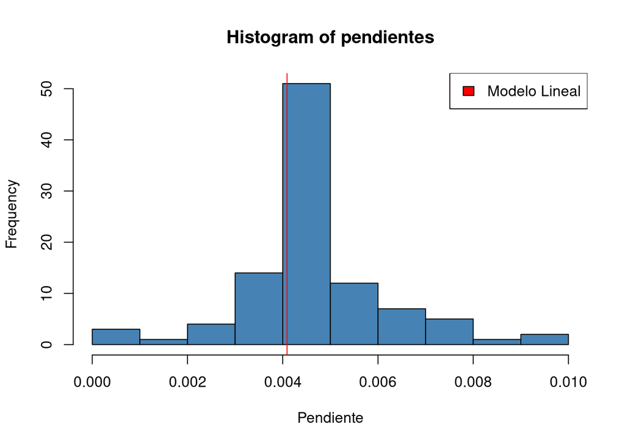

```r
hist(pendientes, xlab = "Pendiente", col="steelblue")
abline(v=lm.params[[2]], col="red")
legend("topright", "Modelo Lineal", fill="red")
```

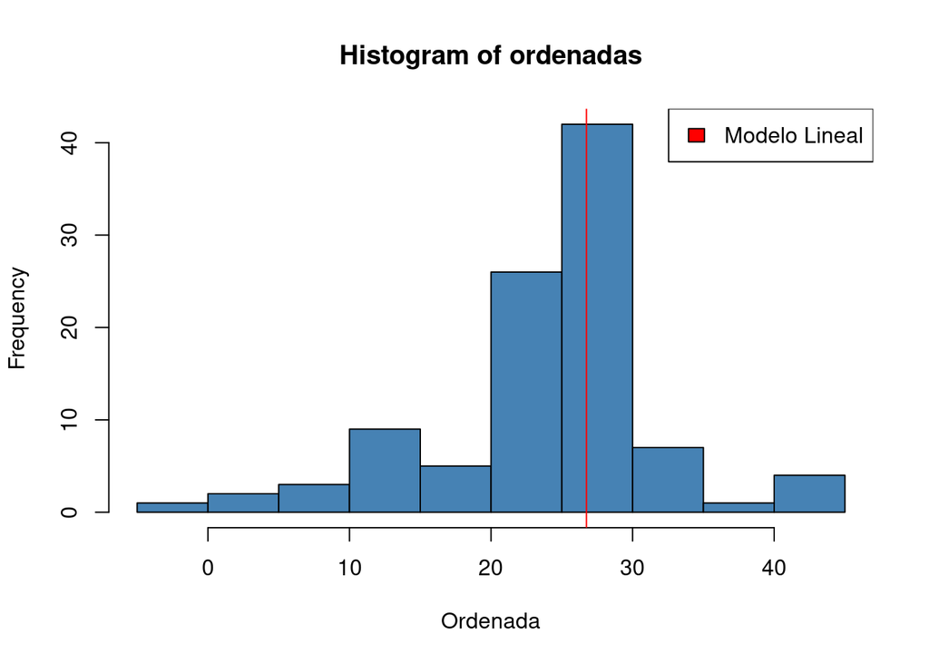

```r
hist(ordenadas, xlab = "Ordenada", col="steelblue")
abline(v=lm.params[[1]], col="red")
legend("topright", "Modelo Lineal", fill="red")
```

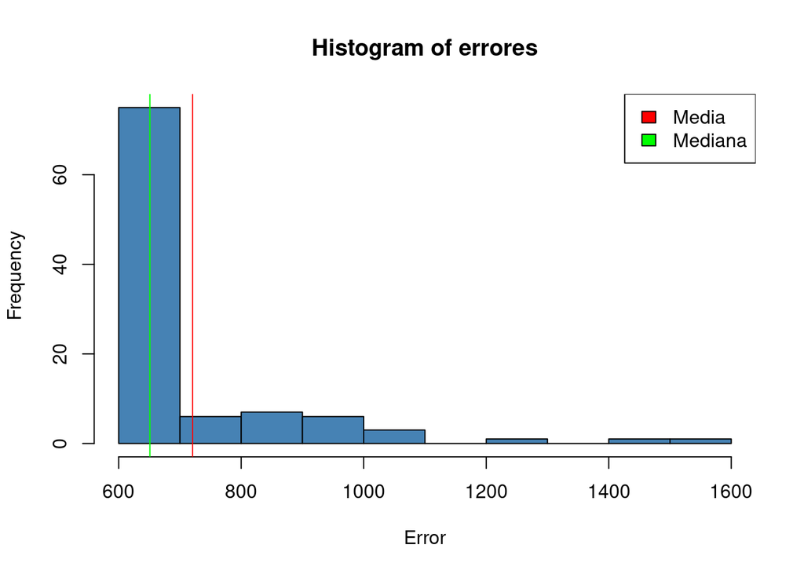

```r
hist(errores, xlab = "Error", col="steelblue")
abline(v=mean(errores), col="red")
abline(v=median(errores), col="green")
legend("topright", c("Media", "Mediana"), fill=c("red", "green"))
```

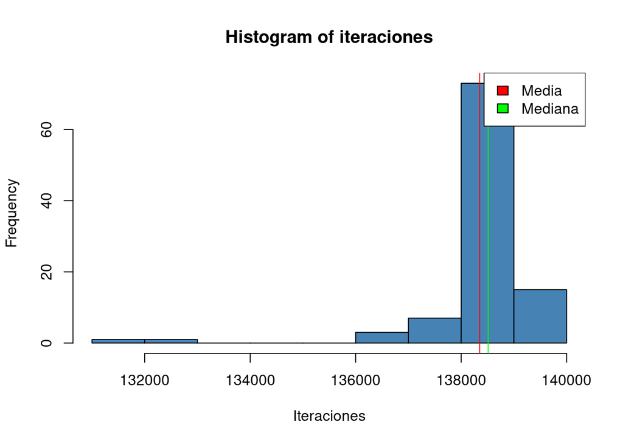

```r
hist(iteraciones, xlab = "Iteraciones", col="steelblue")
abline(v=mean(iteraciones), col="red")
abline(v=median(iteraciones), col="green")
legend("topright", c("Media", "Mediana"), fill=c("red", "green"))
```

f- Cambien la función de pérdida por una que calcule el promedio del error absoluto y estudien si los parámetros estimados son compatibles con los que obtuvieron usando como función de pérdida a la raíz cuadrada del error cuadrático medio.

```r
mean.absolute.error <- function(y.real, y.pred){
    e <- sum( abs(y.real - y.pred) )
    return (e)
}
```

```r
resul.l1 <- optim.aleatoria(datos = datos, loss.fun = mean.absolute.error)

mejor.params.l1 <- resul.l1[[1]][length(resul.l1[[1]][,1]),]
mejor.pendiente.l1 <- mejor.params.l1[2]
mejor.ordenada.l1 <- mejor.params.l1[3]
```

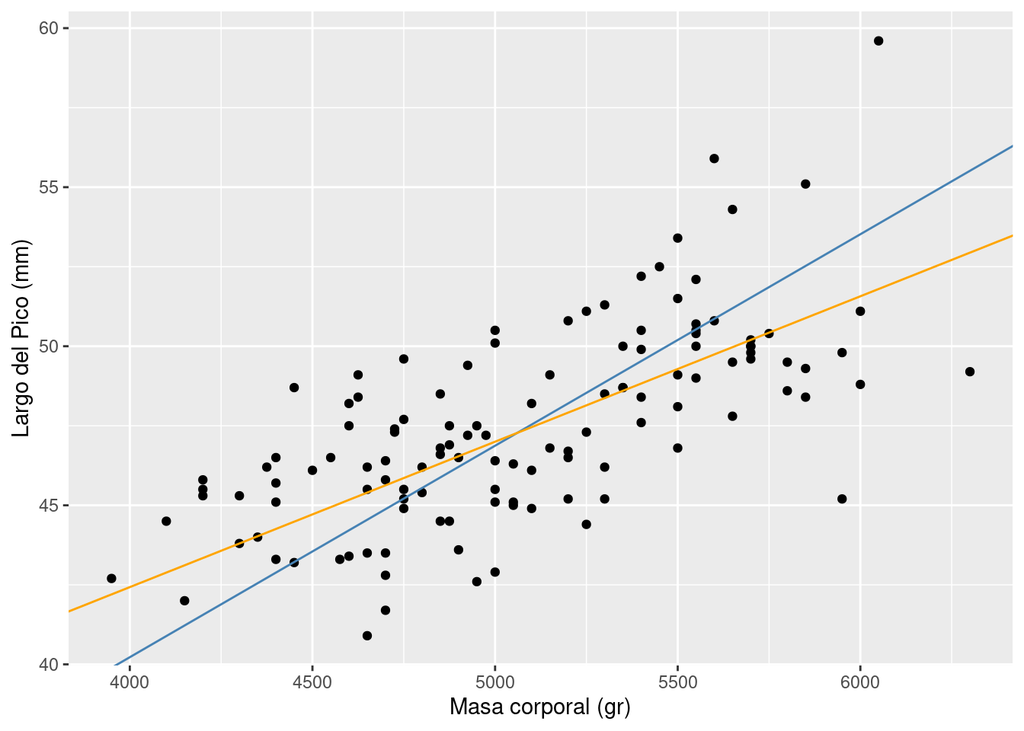

```r
datos %>%
    ggplot(aes(body_mass_g, bill_length_mm)) +
    geom_point() +
    geom_abline(aes(slope=mejor.pendiente, intercept=mejor.ordenada), color="steelblue") +
    geom_abline(aes(slope=mejor.pendiente.l1, intercept=mejor.ordenada.l1), color="orange") +
    labs(x = "Masa corporal (gr)",
         y = "Largo del Pico (mm)",
         color = "Legend") +
    theme(legend.position="right")
```

# Clasificación

### Los 3 elementos del modelado en un problema diferente

El objetivo de este ejercicio es crear los 3 elementos de la tarea de modelado para reconocer el sexo de los pingüinos de la especie Gentoo conociendo sólo la información del peso.

La idea es encontrar una forma de separar a los pingüinos masculinos y femeninos. Vamos a usar lo siguiente:

1. **representación**: si `peso > p0` es masculino. si no, es femenino.
2. **evaluación**: error de clasificación (# de pingüinos clasificados mal)
3. **optimización**: optimización aleatoria.

Por ejemplo, en la figura de abajo se muestra un ejemplo usando como peso de corte p0 = 5300 gramos.

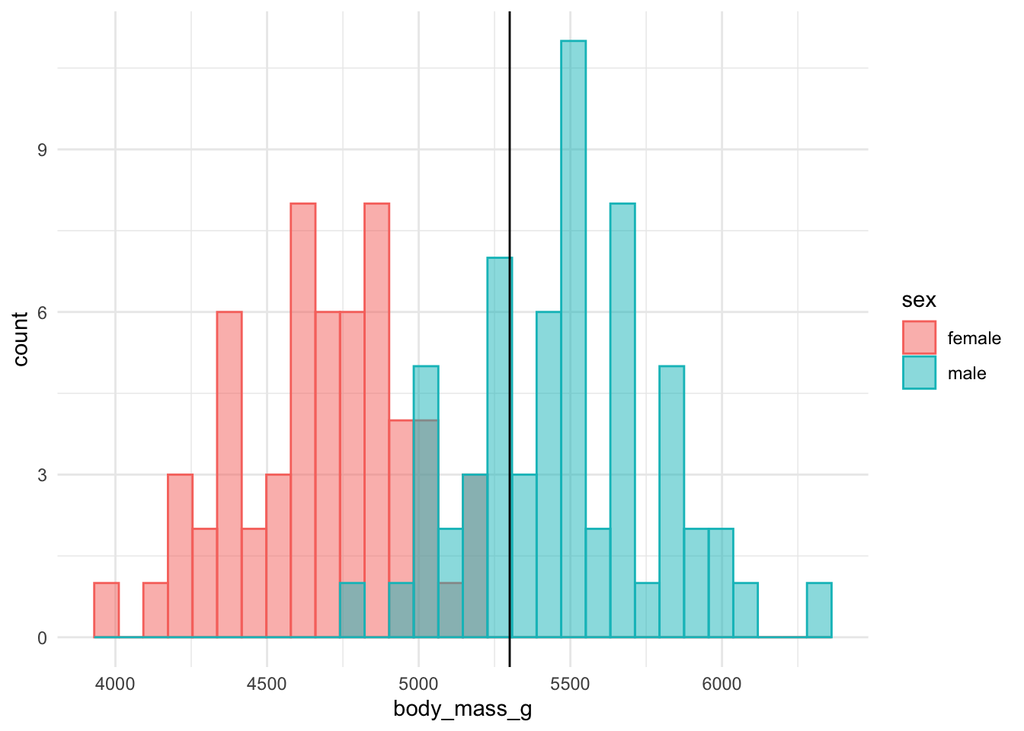

Figura 1

1. Ustedes tienen que encontrar cuál es el mejor peso de corte p0 y cuál es el error para ese criterio.
2. Ahora consideren que pueden usar también el largo del pico. Una posibilidad es dividir al plano con una recta como la de la figura de abajo

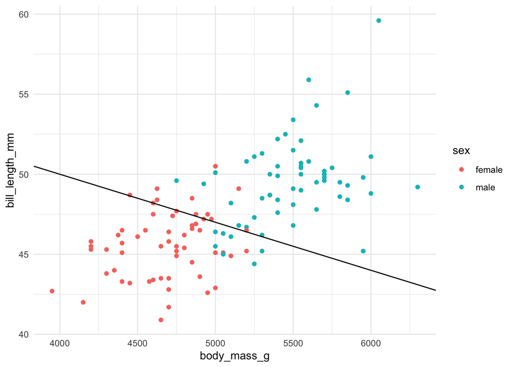

Figura 2

El ejercicio es montar reemplazar el modelo anterior que usaba sólo el peso por uno que usa también el largo del pico. Es decir:

- representación: si `y > a + b x` es masculino. si no, es femenino.
- evaluación: error de clasificación (# de pingüinos clasificados mal)
- optimización: optimización aleatoria.

c- ¿Cuánto mejora la clasificación ahora que incluyeron esta otra variable? ¿Qué pasaría si la recta óptima es una recta vertical? ¿Cómo podrían modificar el modelo para que incluya también el caso de una recta vertical?